## Background & Purpose

We know that socio-demographic factors can affect screening coverage. We produced this tool to look at the impact of these factors on screening coverage at a local level within systems. We have been able to this because data on screening coverage is reported according to the GP practice at which people invited for screening are registered. This is generally considered to be a proxy for other information, such as where people live or the level of deprivation in their area, but this does not imply that screening coverage is the sole responsibility of the GP practice.

This tool models how socio-demographic factors may impact screening coverage to produce an estimated local level which is then compared to the actual screening coverage of each GP practice. This could help identify populations where screening coverage is higher, lower or similar to the level that their socio-demographics would predict, and therefore help systems identify the right strategies to increase screening coverage in those areas.

This tool looks at coverage for bowel screening, rather than uptake. Coverage is the proportion of the eligible population that is screened and has a result documented. By looking at coverage, the data will be less affected by short-term changes to the data and should allow a more accurate estimated level of screening, rather than using uptake.

For further information on the exact modelling used please see the Methodology tab along the top of the tool.

## ICB Focus section

The first section of this tool is the ICB Focus section. Here you will be asked to select the ICB you would like to view the data for, by typing in this box or selecting from the drop-down list.

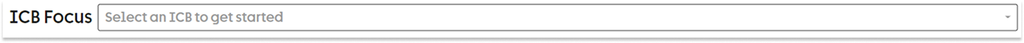

Once an ICB has been selected, the tool highlights how many practice areas are performing higher or lower than the model predicted. By clicking the highlight boxes, you can see a list of practice areas and click the area name to highlight it within the tool.

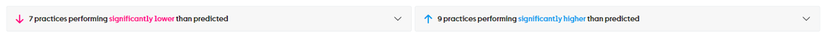

In any of the ICB level views you can hover your mouse over a bar to see the name of the GP practice represented. You can also click on ‘higher’, ‘lower’ or ‘similar’ in the legend at the bottom of the graph to filter which types of practice you want the graph to show.

#### Model prediction compared to screening coverage chart

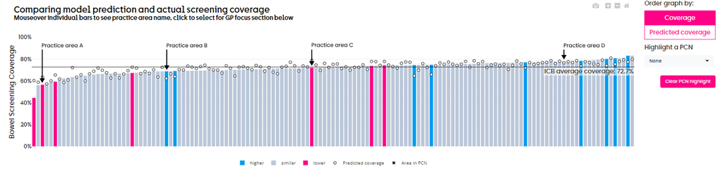

**Figure 1:** This graph shows an ICB-level view, with each GP practice within that ICB displayed as a bar. Please note for this analysis only GPs with a list size of over 1,000 have been included. We’ve annotated a few GP practices to explain what this data shows.

On each of these graphs you can click and drag over an area of the chart to zoom in, or use the plus and minus buttons that appear in the top right corner of the chart when you hover your cursor over it. The house button in the top right corner will reset your view if you have zoomed in.

**Practice area A**

Practice area A is highlighted in pink, which indicates the practice area’s screening coverage is lower than our model estimated it would be. We can also see practice area A’s screening coverage is below the ICB average of 72.7%.

This could mean practice area A could benefit from some local interventions or support from an ICB or PCN level.

**Practice area B**

In contrast, practice area B is highlighted in blue, which means that the area’s screening coverage is higher than our model estimated it would be based on local factors. This may be because the GP is in a more deprived area, or has a small population of screening age, which this model would take into account when estimating coverage.

While practice area B is still below the ICB average, it may have some positive practice in place that practice area A could benefit from.

**Practice area C**

Practice area C is highlighted in pink which means that, although the practice area’s coverage is higher than the ICB average, the screening coverage is not as high in the population as we would expect based when local demographic factors are taken into account.

This means they might not be an area for immediate ICB prioritisation, but there may be improvements that could help this area achieve even higher screening numbers.

**Practice area D**

Practice area D is performing approximately as our model calculated it would, so is highlighted in grey. It’s worth noting that practices highlighted in grey may be above or below the ICB average, or other performance targets. Therefore, it’s important to view this tool alongside other local data when making decisions about areas to support with their bowel screening.

In the top-right corner of the chart of GP practices by predicted performance, there is also a button to allow you to order the graph by the model’s predicted coverage for each GP practice.

### Standardised screening ratio chart

This chart is useful to understand how big the difference is between the model’s prediction and the observed screening levels.

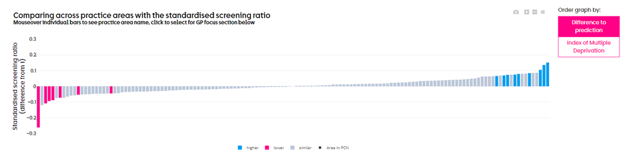

**Figure 2:** The next view seen in the tool is this view, which looks at the difference from 1 in our standardised screening ratio (SSR)

The SSR is the observed coverage divided by the predicted coverage for a practice area. If a practice screens the same number of people as our model predicts, then the standardised screening ratio would be 1. This graph is showing the difference above or below a SSR of 1, so how big the difference between the prediction from our model is to each practice’s actual coverage. SSR should be considered alongside list size in order to understand potential room for improvement, for example a large negative SSR may be calculated for a small practice so the number of unscreened patients is not as high as a larger practice with a smaller negative SSR.

This might be a useful starting point for considering which local areas might be a priority for further support or learning.

In any of the ICB level views you can hover your mouse over a bar to see the name of the GP practice local to a population represented. You can also click on ‘higher’, ‘lower’ or ‘similar’ in the legend at the bottom of the graph to filter on which types of practice you want the graph to show.

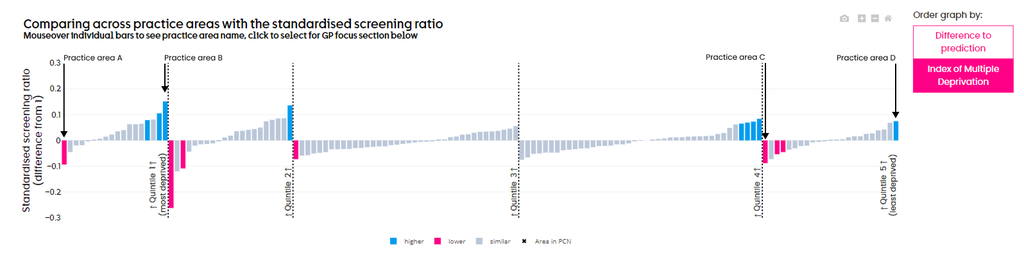

Figure 3: The above chart shows the practices grouped by their IMD quintile and then ordered by their difference from one in the standardised screening ratio. As in the above graphs those practice areas highlighted in blue represent where areas are performing statistically significantly higher than our model estimated, and those in pink below what our model estimated. Again, we have highlighted a few practices to explore what this may mean for local context.

Having selected the option to order this graph by Index of Multiple Deprivation (IMD), the chart will automatically group the practice area’s according to their IMD quintile as seen in figure 3. Using this chart, we can see that practice area A is in the most deprived quintile, and has significantly lower bowel screening coverage than our model predicts.

In contrast, practice area B is also in the most deprived quintile but is screening statistically significantly more people than our model estimated. This could mean that from an ICB-view there may be positive learning or campaigns taking place in the practice area of practice area B which could be positive to share or look to implement within practice area A. These interventions may be more applicable as they have some overlap with populations in terms of their level of deprivation.

Similarly in the least deprived quintile we can see there is practice area C screening fewer people than our model expected, while practice area D screened more than expected. This may also be an opportunity for sharing learning and best practice at a local level to find improvements that work for local populations.

It's important to remember than any of the above practices may be performing above or below national performance targets. While our tool may help in identifying areas needing support or areas showcasing best practice, it is always important to understand the unique individual context each area is experiencing. Absolute coverage is also important to keep in mmind when reviewing this data to avoid reinforcing inequalities and ensuring bowel screening is being made as accessible as possible to all communities.

## Practice population level data view

Below the ICB level view, you will come to a GP level view. You will be asked to search for the GP you would like to view the data for, by typing in this box or selecting from the drop-down list.

[figure not shown]

This will then populate the below table and chart with the data for your selected GP practice population. You can also select a GP by clicking on the any of the bars in the ICB level views. Selecting a GP from the above menu will also then highlight that practice on the ICB level view charts.

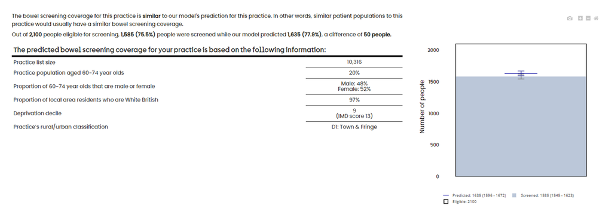

You will also be able to see the coverage percentage for your area, which could be compared to the ICB average above, or national performance targets.

There is also a further GP-specific breakdown of the practice list size, proportion of population aged 60-74, split by sex, proportion of residents who are white British in the GP area, the deprivation decile and IMD score, and the practice’s rural/urban classification. All of these factors could influence the type of interventions you may want to consider implementing to improve screening coverage for bowel cancer.

Please note that we currently do not have demographic data for homelessness, learning disabilities and severe mental illness, granular ethnicity split, etc. factored into our model. Please use existing local data and knowledge to support your use of this tool.

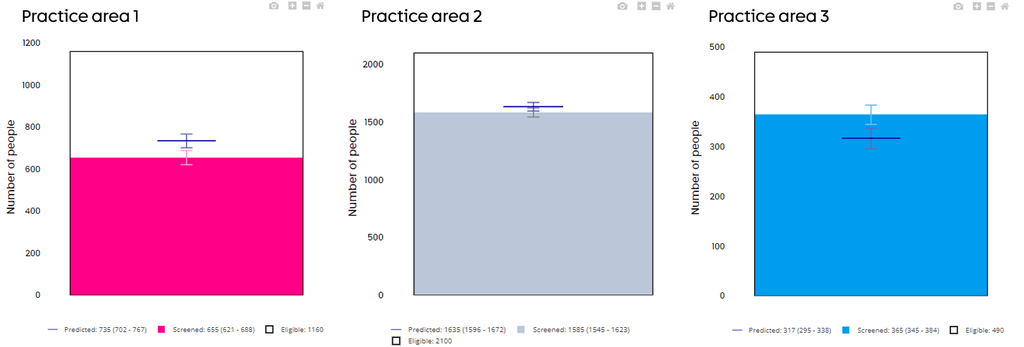

**Figure 5**: In this GP level view, you can also see a box and whisker plot to show the confidence intervals around the actual and predicted coverage numbers.

**Practice Area 1** has a pink bar, meaning the practice area has significantly lower coverage than our model estimated based on local factors.

- In the box and whisker plot for this area we can see the black outline indicating that 1,160 people are eligible for screening in this area, with that number notes in the legend below the plot.
- The pink area of this box shows that of the 1,160 people eligible, 655 were screened in our data. The light pink lines around the top of this pink area show the confidence intervals calculated for this number of people screened.
- The wider navy line sitting above the pink area show the number our model estimated would be screened in this area, with the confidence intervals shown above and below this. We can see that the pink confidence intervals around the actual screening coverage do not overlap with the navy confidence intervals of the model’s estimated coverage, therefore this difference is statistically significant.

**Practice Area 3** has a blue bar, meaning the practice area has significantly higher coverage than our model estimated based on local factors.

- In the box and whisker plot for this area we can see the black outline indicating that 490 people are eligible for screening in this area.
- The blue area of this box shows that of the 490 people eligible, 365 were screened in our data. The light blue lines around the top of this blue area show the confidence intervals calculated for this number of people screened.
- The wider navy line sitting below the blue area show the number our model estimated would be screened in this area, with the confidence intervals shown above and below this. We can see that the blue confidence intervals around the actual screening coverage do not overlap with the navy confidence intervals of the model’s estimated coverage, therefore this difference is statistically significant.